# hw5

Name: Sonia Thomas github username: sthomas20

3/9/2020

## Liquor Sales in Iowa

This dataset https://data.iowa.gov/Sales-Distribution/2019-Iowa-Liquor-Sales/38x4-vs5h contains the spirits purchase information of Iowa Class “E” liquor licensees by product and date of purchase for 2019. The dataset can be used to analyze total spirits sales in Iowa of individual products at the store level.

**Submission instructions**: Create a folder named `ds202_hw5`, and name the RMarkDown file including your solutions `hw5.Rmd` under this folder. For the submission, create a GitHub repository named `ds202_hw5` under your GitHub account, and push both `hw5.Rmd` and the knitted `hw5.html` before the deadline. I will assume you use the same GitHub username as for your HW4 submission. The latest version of your homework appearing on GitHub before the deadline is graded. *It is crucial to follow the exact folder structure and file names*, so that your homework can be reproduced and graded by an automated script. This homework is **due on April 10** by 11:59 pm.

1. The complete dataset is too large. Download and import the alcohol sales data for Ames only:
1. Go to https://data.iowa.gov/Sales-Distribution/2019-Iowa-Liquor-Sales/38x4-vs5h
2. Click Filter – Filter – Go advanced now
3. Add a New Filter Condition: City is Ames.
4. Export – CSV – Download
5. Use `readr::read_csv` to import.

```r
#used session-> set working directory -> to source file location
ames<- read_csv("2019_Iowa_Liquor_Sales.csv")
```

2. Data cleaning:
1. extract geographic latitude and longitude from the variable `Store Location`
2. make sure the variables are in the correct type, by converting incorrect variable types.
3. extract year, month and day from the variable `Date` as separate columns.

```r
#Question 2a
store_location<- ames[ , "Store Location"]
store_location <- separate(store_location, "Store Location", into = c("latitude", "longitude"), sep = " (?=[^ ]+$)")

store_location$latitude<- gsub("POINT \\(", "", store_location$latitude)
store_location$longitude<- gsub("\\)", "", store_location$longitude)

#Question 2b
store_location$latitude<- as.double(store_location$latitude)
store_location$longitude<- as.double(store_location$longitude)
ames$store_location <- store_location


#Question 2c
ames$date_new <- as.Date(ames$Date, "%m/%d/%Y")
ames$Month<- months(ames$date_new)
ames$Day <- day(ames$date_new)
ames$Year <- year(ames$date_new)
```

3. First overview:
1. Plot a scatterplot of lat and long of store locations.
2. Provide a visual breakdown of the liquor category (by `Category Name`). Include volume sold in the breakdown.

[figure not shown]

```r
#Question 3a
ggplot(ames$store_location, aes(x=latitude, y=longitude)) + geom_point() + xlab("Latitude") + ylab("Longitude") + ggtitle("Latitude and Longtiude Scatterplot")
```

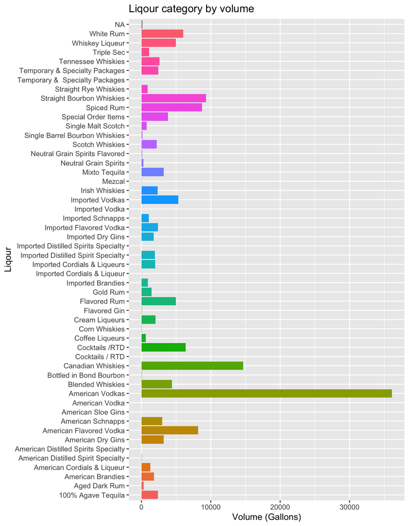

```r
#Question 3b
ames %>%
  group_by(`Category Name`) %>%
  summarise(total_vol = sum(`Volume Sold (Gallons)`)) %>%
  ggplot(ames, mapping = aes(x=`Category Name`, y = total_vol, fill=`Category Name`)) + geom_col() + coord_flip() + xlab("Liqour") + ylab('Volume (Gallons)') + ggtitle('Liqour category by volume') + theme(legend.position = "none")
```

4. Find the daily sales liquor sales in Ames in 2019. Summarize the number of sales, volume of liquor sold, and amount of money spent.

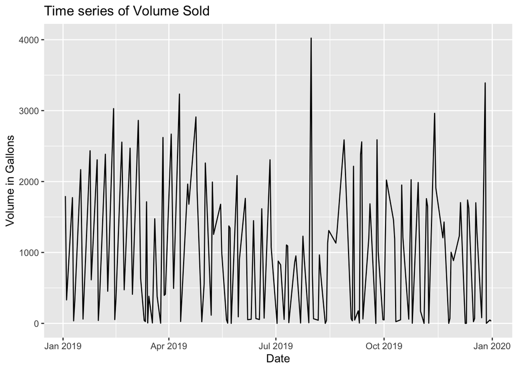

```r
ames %>%
  group_by(date_new) %>%
  summarise(Volume_of_liq_sold = sum(`Volume Sold (Gallons)`)) %>%
  ggplot(ames, mapping = aes(date_new, y=Volume_of_liq_sold)) + geom_line() + scale_x_date() + ylab('Volume in Gallons') + xlab('Date') + ggtitle("Time series of Volume Sold")
```

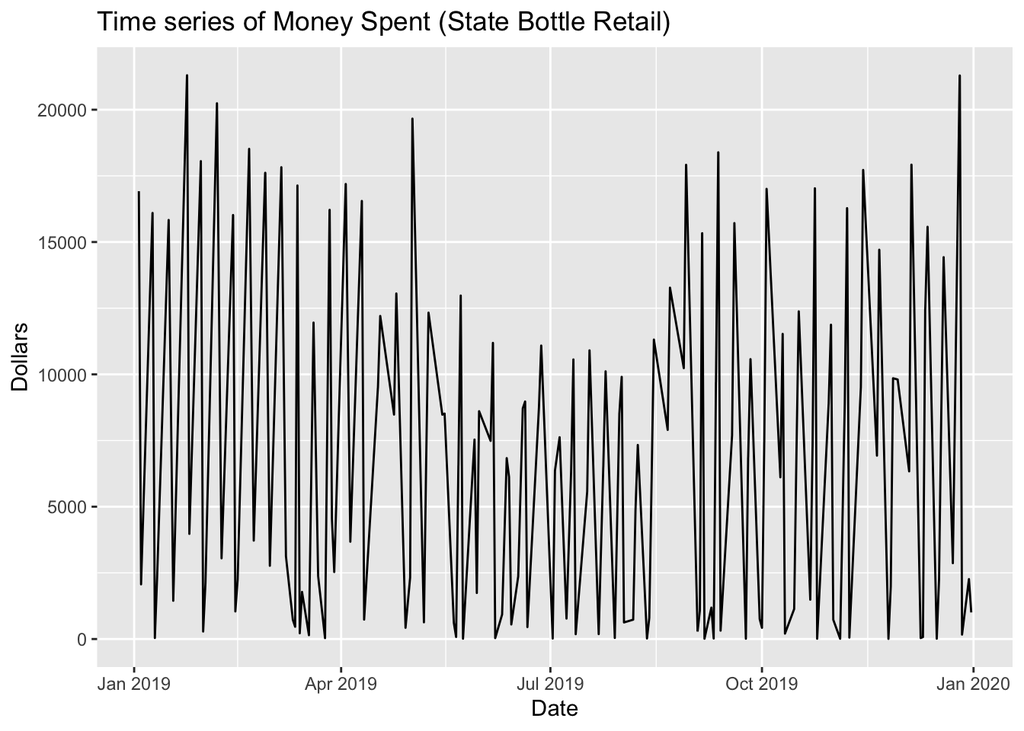

```r
ames %>%
  group_by(date_new) %>%
  summarise(money_spent = sum(`State Bottle Retail`)) %>%
  ggplot(ames, mapping = aes(date_new, y=money_spent)) + geom_line() + scale_x_date() + xlab('Date') + ylab('Dollars') + ggtitle("Time series of Money Spent (State Bottle Retail)")
```

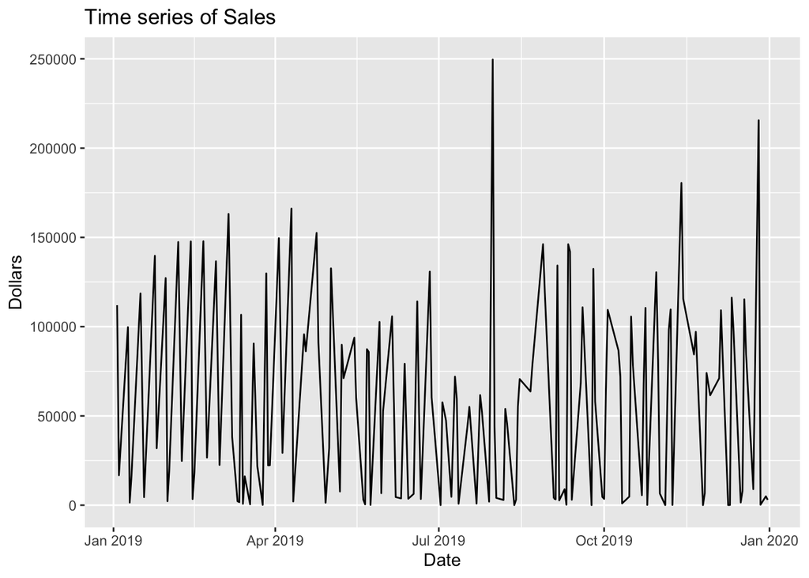

```r
ames %>%
  group_by(date_new) %>%
  summarise(num_sales= sum(`Sale (Dollars)`)) %>%
  ggplot(ames, mapping = aes(date_new, y=num_sales)) + geom_line() + scale_x_date() + xlab('Date') + ylab('Dollars') + ggtitle("Time series of Sales")
```

Based on the output above you can see that the all three of the graphs tend to sharply spike up and down through out the months. You can see that the first and third graph have their highest spikes during similar times.

5. Plot volume sold by day (use a scatterplot of volume by day and facet by month). Discover trends with the help of `geom_smooth`. Describe any patterns.

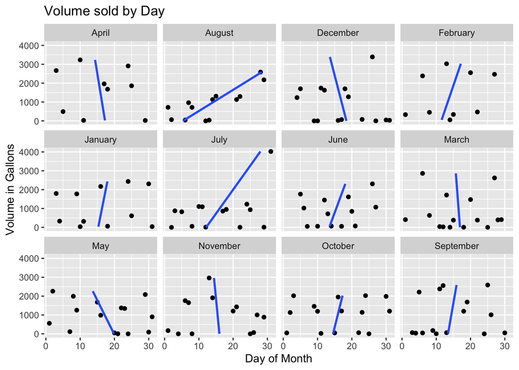

```r
ames %>%
  group_by(Day, Month) %>%
  summarise(volume_by_day = sum(`Volume Sold (Gallons)`)) %>%
  ggplot(ames, mapping = aes(x=volume_by_day, y=Day)) + geom_point() + facet_wrap(~Month) + coord_flip() + geom_smooth(method = lm, se = FALSE ) + ylab('Day of Month') + xlab('Volume in Gallons') + ggtitle('Volume sold by Day')
```

6. Find the dates for ISU football home games in Fall 2019. Can you see a pattern?

[figure not shown]

```r
#found the dates of the ISU 2019 Home cames here https://cyclones.com/sports/football/schedule/2019

ISU_date<- c("08/31/2019", "09/14/2019", "09/21/2019", "10/05/2019", "10/26/2019", "11/16/2019", "11/23/2019")

ames$home_game = (ames$Date %in% ISU_date)

ames %>%
  ggplot(ames, mapping = aes(x=date_new, y = `Sale (Dollars)`, fill= home_game)) + geom_col() + xlab('Date') + ylab('Dollars') + ggtitle("Liqour Sales during 2019 ISU Football Home Games")
```

Note: your submission is supposed to be fully reproducible, i.e. the TA and I will ‘knit’ your submission in RStudio.